# Bayesian Data Analysis Assignment 1

Johnny Lee (s1687781)

7th.Mar.2022

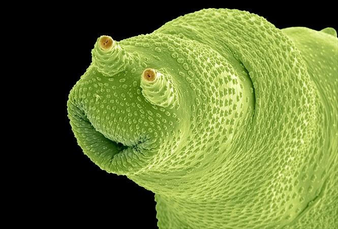

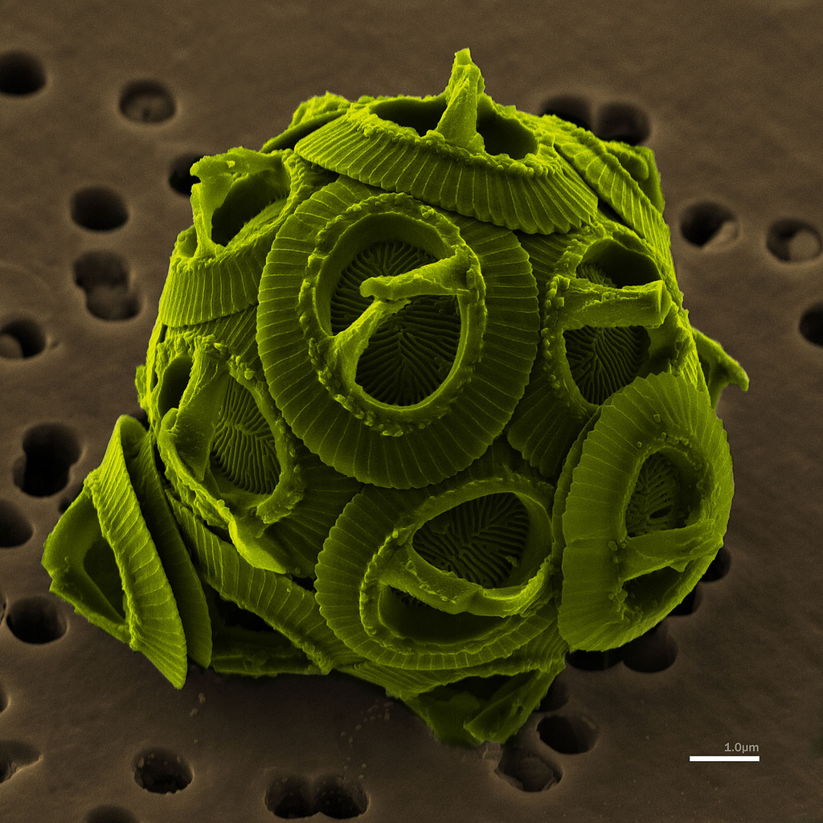

The first picture is a rotifier (by Steve Gschmeissner), the second is a unicellular algae (by NEON ja, colored by Richard Bartz).

**Problem 1 - Rotifier and algae data**

**In this problem, we study an experimental dataset (Blasius et al. 2020, https://doi.org/10.1038/s41586-019-1857-0) about predator-prey relationship between two microscopic organism: rotifier (predator) and unicellular green algae (prey). These were studied in a controlled environment (water tank) in a laboratory over 375 days. The dataset contains daily observations of the concentration of algae and rotifiers. The units of measurement in the algae column is** $\mathbf{10^6}$ **algae cells per ml of water, while in the rotifier column it is the number of rotifiers per ml of water.**

**We are going to apply a simple two dimensional state space model on this data using JAGS. The first step is to load JAGS and the dataset.**

```r
rotifier_algae <- read.csv("rotifier_algae.csv")
#The first 6 rows of the dataframe
print.data.frame(rotifier_algae[1:6,])
```

```
##   day algae rotifier
## 1   1  1.50       NA
## 2   2  0.82     6.58
## 3   3  0.77    17.94
## 4   4  0.36    17.99
## 5   5  0.41    21.12
## 6   6  0.41    17.06
```

**As we can see, some values in the dataset are missing (NA)**.

**We are going to model the true log concentrations** $\mathbf{x}_t$ **by the state space model**
$$\mathbf{x}_t = \mathbf{A} \mathbf{x}_{t-1}+\mathbf{b}+\mathbf{w}_t; \quad \mathbf{w}_t\sim N\left(0,\left(\begin{matrix}\sigma_R^2 & 0\\ 0 & \sigma_A^2\end{matrix}\right)\right)$$
**where** $\mathbf{A}$**,** $\mathbf{b}$, $\sigma^2_R$ **and** $\sigma^2_A$ **are model parameters, and** $t$ **denotes the time point. In particular,** $t=0$ **corresponds to day 0, and** $t=1,2,\ldots, 375$ **correspond to days 1-375.**

**Here** $\mathbf{x}_t$ **is a two dimensional vector. The first component denotes the logarithm of the rotifier concentration measured in number of rotifiers per ml of water, and the second component denotes the logarithm of the algae concentration measured in** $10^6$ **algae per ml (these units are the same as in the dataset).** $\mathbf{A}=\left(\begin{matrix}A_{11} & A_{12}\\ A_{21} & A_{22}\end{matrix}\right)$ **is a two times two matrix, and** $\mathbf{b}$ **is a two dimensional vector.**

**The observation process is described as**
$$\mathbf{y}_t =\mathbf{x}_{t}+\mathbf{v}_t, \quad \mathbf{v}_t\sim N\left(0,\left(\begin{matrix}\eta_R^2 & 0\\ 0 & \eta_A^2\end{matrix}\right)\right),$$

**where** $\mathbf{y}_t$ **is the observed log concentration on day** $t$ **(for example,** $\mathbf{y}_2=\left(\begin{matrix}\log(6.58)\\ \log(0.82)\end{matrix}\right)$ **in our dataset), while** $\eta_R^2$ **and** $\eta_R^2$ **are additional model parameters.**

**a)[10 marks] Create a JAGS model that fits the above state space model on the rotifier-algae dataset for the whole 375 days period.**

**Use 10000 burn-in steps and obtain 50000 samples from the model parameters** $\mathbf{A}, \mathbf{b}, \sigma_R^2, \sigma_A^2, \eta_R^2, \eta_A^2$ **(4+2+4=10 parameters in total).**

**Use a Gaussian prior** $N\left(\left(\begin{matrix}\log(6)\\ \log(1.5) \end{matrix}\right), \left(\begin{matrix}4 & 0\\ 0 & 4\end{matrix}\right) \right)$ **for the initial state** $\mathbf{x}_0$**, independent Gaussian** $N(0,1)$ **priors for each 4 elements of** $\mathbf{A}$, **Gaussian prior** $N\left(\left(\begin{matrix}0\\ 0 \end{matrix}\right), \left(\begin{matrix}1 & 0\\ 0 & 1\end{matrix}\right) \right)$ **for** $\mathbf{b}$**, and inverse Gamma (0.1,0.1) prior for the variance parameters** $\sigma_R^2, \sigma_A^2, \eta_R^2, \eta_A^2$**.**

**Explain how did you handle the fact that some of the observations are missing (NA) in the dataset.**

**Explanation**:

From running the `summary()` function, we can observe $7$ and $8$ missing values for algae and rotifier respectively. The column rotifier has additionally missing value which appears in Day 1 and the rest of the missing values occurs in pair on the same day. Since the data is a time series data, omitting nor imputing the values will change the distribution and the decrease the variance of the data thus effect the distribution of prior/likelihood. Taking note that the covariance matrices are diagonal matrices, we can then assume the independence of algae and rotifier. Thus, in JAGS, we do not have to define the model string as multivariate normal distribution but as a univariate normal distribution. Also, we take the advantage of dealing the missing values here as JAGS automatically takes into account of the missing values in algae and rotifier data. Therefore, we do not make imputation nor omit the missing values.

```r
summary(rotifier_algae)
```

```
##       day            algae           rotifier
##  Min.   :  1.0   Min.   :0.0800   Min.   :  2.82
##  1st Qu.: 94.5   1st Qu.:0.3100   1st Qu.: 17.61
##  Median :188.0   Median :0.4450   Median : 24.94
##  Mean   :188.0   Mean   :0.5223   Mean   : 28.45
##  3rd Qu.:281.5   3rd Qu.:0.6600   3rd Qu.: 35.65
##  Max.   :375.0   Max.   :1.9300   Max.   :228.99
##                  NA's   :7        NA's   :8
```

```r
head(rotifier_algae, 10)
```

```
##    day algae rotifier
## 1    1  1.50       NA
## 2    2  0.82     6.58
## 3    3  0.77    17.94
## 4    4  0.36    17.99
## 5    5  0.41    21.12
## 6    6  0.41    17.06
## 7    7  0.90    17.00
## 8    8  0.29    36.15
## 9    9  0.72    19.84
## 10  10  0.46    30.82
```

```r
#defining the total number of days
n <- nrow(rotifier_algae) + 1
#defining the log concentration for each rotifier and algae
y1 <- c(NA, log(rotifier_algae[, 3]))
y2 <- c(NA, log(rotifier_algae[, 2]))
```

```r
model.string <- "model {

x1[1] ~ dnorm(mean.x01, tau.x0)
x2[1] ~ dnorm(mean.x02, tau.x0)

a11 ~ dnorm(mean.a, tau.a)
a12 ~ dnorm(mean.a, tau.a)
a21 ~ dnorm(mean.a, tau.a)
a22 ~ dnorm(mean.a, tau.a)

b1 ~ dnorm(mean.b, tau.b)
b2 ~ dnorm(mean.b, tau.b)

tau.sigma2r ~ dgamma(sigma.a, sigma.b)
tau.sigma2a ~ dgamma(sigma.a, sigma.b)
tau.eta2r ~ dgamma(eta.a, eta.b)
tau.eta2a ~ dgamma(eta.a, eta.b)


sigma2r <- 1/tau.sigma2r
sigma2a <- 1/tau.sigma2a
eta2r <- 1/tau.eta2r
eta2a <- 1/tau.eta2a

for (i in 2:n){
  x1[i] ~ dnorm(a11*x1[i-1] + a12*x2[i-1] + b1, tau.sigma2r)
  x2[i] ~ dnorm(a21*x1[i-1] + a22*x2[i-1] + b2, tau.sigma2a)

}

for (i in 1:n){
  y1[i] ~ dnorm(x1[i], tau.eta2r)
  y2[i] ~ dnorm(x2[i], tau.eta2a)
}
}"
```

```r
#initialising the values for JAGS model
#initialising log concentration, x
mean.x01 <- log(6); mean.x02 <- log(1.5); tau.x0 <- 1/4

#initialising A and b
mean.a <- mean.b <- 0
tau.a <- tau.b <- 1

#initialising the noise sigma and eta
sigma.a <- sigma.b <- eta.a <- eta.b <- 0.1

model.data <- list(n = n, y1 = y1, y2 = y2, mean.x01 = mean.x01,
                   mean.x02 = mean.x02, tau.x0 = tau.x0,
                   mean.a = mean.a, tau.a = tau.a,
                   mean.b = mean.b, tau.b = tau.b, sigma.a = sigma.a,
                   sigma.b = sigma.b, eta.a = eta.a, eta.b = eta.b)
```

```r
#Defining the state space model in JAGS
model <- jags.model(textConnection(model.string),
                    data = model.data, n.chains = 1)
#Burnin for 10000 samples
update(model, 10000, progress.bar="none")
#Running the model, monitoring A, b, sigma23, sigma2a, eta2r, eta2a
#with 50000 iterations
res <- coda.samples(model,
                        variable.names=c("a11", "a12", "a21", "a22",
                                         "b1", "b2", "sigma2r","sigma2a",
                                         "eta2r","eta2a"),
                        n.iter = 50000, progress.bar="none")
```

```r
#summary statistics
summary(res)
```

```
##
## Iterations = 10001:60000
## Thinning interval = 1
## Number of chains = 1
## Sample size per chain = 50000
##
## 1. Empirical mean and standard deviation for each variable,
##    plus standard error of the mean:
##
##             Mean       SD  Naive SE Time-series SE
## a11      0.57302 0.044706 1.999e-04      0.0021816
## a12      0.59205 0.085489 3.823e-04      0.0033134
## a21     -0.42386 0.048192 2.155e-04      0.0022214
## a22      0.25720 0.058341 2.609e-04      0.0009881
## b1       1.84645 0.136075 6.085e-04      0.0062917
## b2       0.74052 0.157503 7.044e-04      0.0074128
## eta2a    0.08744 0.030595 1.368e-04      0.0012603
## eta2r    0.02723 0.008671 3.878e-05      0.0002292
## sigma2a  0.16886 0.032521 1.454e-04      0.0011999
## sigma2r  0.13070 0.019554 8.745e-05      0.0005887
##
## 2. Quantiles for each variable:
##
##             2.5%      25%      50%      75%   97.5%
## a11      0.48812  0.54282  0.57198  0.60224  0.6620
## a12      0.44692  0.53178  0.58381  0.64339  0.7836
## a21     -0.51835 -0.45682 -0.42451 -0.39031 -0.3313
## a22      0.14122  0.21834  0.25780  0.29644  0.3707
## b1       1.58769  1.75450  1.84573  1.93609  2.1192
## b2       0.43207  0.63335  0.74412  0.84848  1.0481
## eta2a    0.03270  0.06523  0.08600  0.10813  0.1507
## eta2r    0.01370  0.02083  0.02613  0.03238  0.0471
## sigma2a  0.10904  0.14569  0.16792  0.19113  0.2344
## sigma2r  0.09069  0.11818  0.13122  0.14373  0.1678
```

**b)[10 marks]**

**Based on your MCMC samples, compute the Gelman-Rubin convergence diagnostics (Hint: you need to run multiple chains in parallel for this by setting the n.chains parameter). Discuss how well has the chain converged to the stationary distribution based on the results.**

**Print out the summary of the fitted JAGS model. Do autocorrelation plots for the 4 components of the model parameter** $\mathbf{A}$**.**

**Compute and print out the effective sample sizes (ESS) for each of the model parameters** $\mathbf{A}, \mathbf{b}, \sigma_R^2, \sigma_A^2, \eta_R^2, \eta_A^2$**.**

**If the ESS is below 1000 for any of these 10 parameters, increase the sample size/number of chains until the ESS is above 1000 for all 10 parameters.**

**Explanation**:

Last but not least, the trace plots of all the components indicated good mixing as there are no significant patterns sticking out of the trace plots. To that, we tabulated the effective size for each parameters and confirmed that their effective size is greater than $1000$.

```r
#Defining the JAGS model with 5 chains
model.chain <- jags.model(textConnection(model.string),
                    data = model.data, n.chain = 5)
#Burning for 10000 samples
update(model.chain, 10000, progress.bar = "none")
#Running the model, monitoring A, b, sigma23, sigma2a, eta2r, eta2a
#with 130000 iterations
res.chain <- coda.samples(model.chain,
                        variable.names = c("a11", "a12", "a21", "a22",
                                         "b1", "b2", "sigma2r","sigma2a",
                                         "eta2r","eta2a"),
                        n.iter = 130000, progress.bar="none")
```

```r
summary(res.chain)
```

```
##
## Iterations = 10001:140000
## Thinning interval = 1
## Number of chains = 5
## Sample size per chain = 130000
##
## 1. Empirical mean and standard deviation for each variable,
##    plus standard error of the mean:
##
##             Mean       SD  Naive SE Time-series SE
## a11      0.57429 0.045061 5.589e-05      6.195e-04
## a12      0.60052 0.087756 1.088e-04      9.834e-04
## a21     -0.42251 0.048639 6.033e-05      6.298e-04
## a22      0.25699 0.058638 7.273e-05      2.970e-04
## b1       1.84936 0.138649 1.720e-04      1.800e-03
## b2       0.73596 0.157726 1.956e-04      2.056e-03
## eta2a    0.09033 0.030313 3.760e-05      3.524e-04
## eta2r    0.02734 0.008412 1.043e-05      6.387e-05
## sigma2a  0.16610 0.031953 3.963e-05      3.369e-04
## sigma2r  0.12965 0.019382 2.404e-05      1.713e-04
##
## 2. Quantiles for each variable:
##
##             2.5%      25%      50%      75%    97.5%
## a11      0.48776  0.54405  0.57341  0.60331  0.66592
## a12      0.45180  0.53802  0.59266  0.65448  0.79514
## a21     -0.51978 -0.45484 -0.42234 -0.38953 -0.32875
## a22      0.13985  0.21814  0.25766  0.29667  0.36994
## b1       1.57467  1.75701  1.84971  1.94162  2.12137
## b2       0.42946  0.62936  0.73584  0.84155  1.04790
## eta2a    0.03590  0.06832  0.08914  0.11094  0.15232
## eta2r    0.01389  0.02123  0.02634  0.03237  0.04642
## sigma2a  0.10686  0.14338  0.16515  0.18789  0.23035
## sigma2r  0.09028  0.11700  0.12999  0.14267  0.16695
```

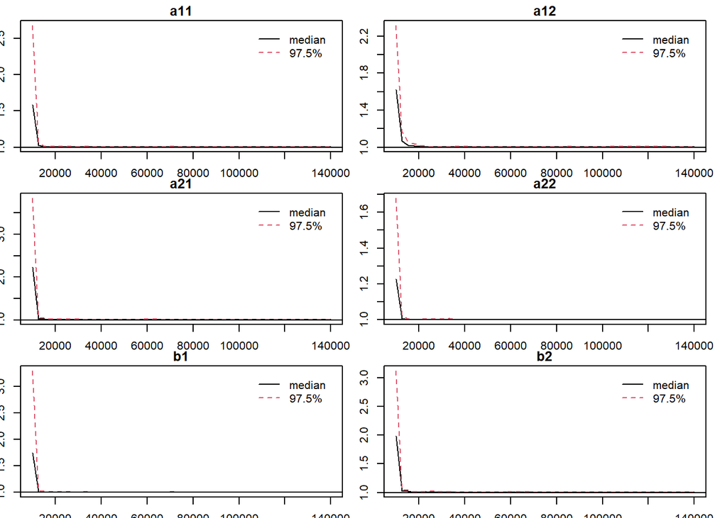

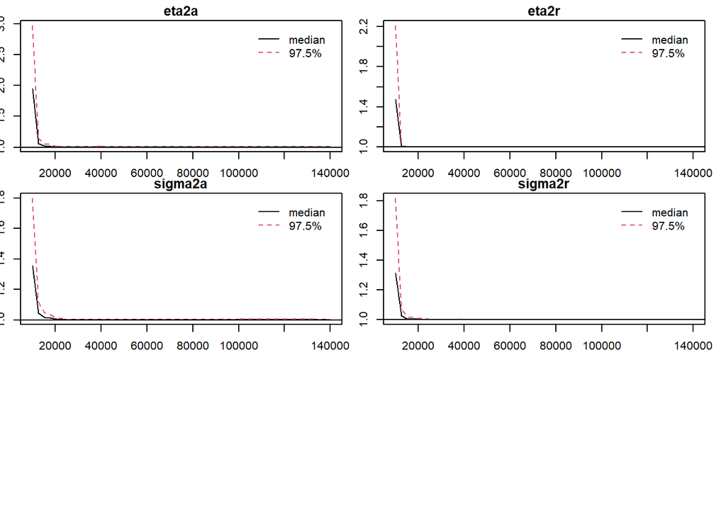

```r
#Computing Gelman-Rubin statistics
par(mfrow=c(3,2),mar=c(1.5,1.5,1.5,1.5))
gelman.plot(res.chain)
```

```r
gelman.diag(res.chain)
```

```
## Potential scale reduction factors:
##
##         Point est. Upper C.I.
## a11              1       1.00
## a12              1       1.00
## a21              1       1.01
## a22              1       1.00
## b1               1       1.00
## b2               1       1.01
## eta2a            1       1.00
## eta2r            1       1.00
## sigma2a          1       1.00
## sigma2r          1       1.00
##
## Multivariate psrf
##
## 1
```

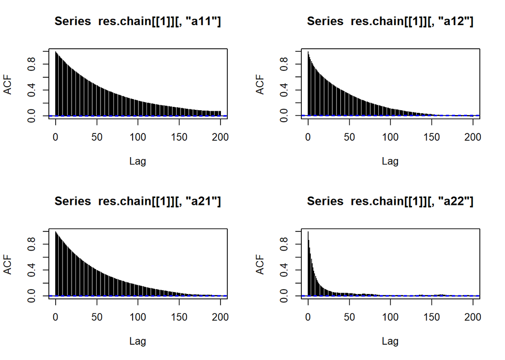

```r
#Computing Autocorrelation plot for the 4 components of the model parameter A
par(mfrow=c(2,2))
acf(res.chain[[1]][,"a11"], lag.max=200)
acf(res.chain[[1]][,"a12"], lag.max=200)
acf(res.chain[[1]][,"a21"], lag.max=200)
acf(res.chain[[1]][,"a22"], lag.max=200)
```

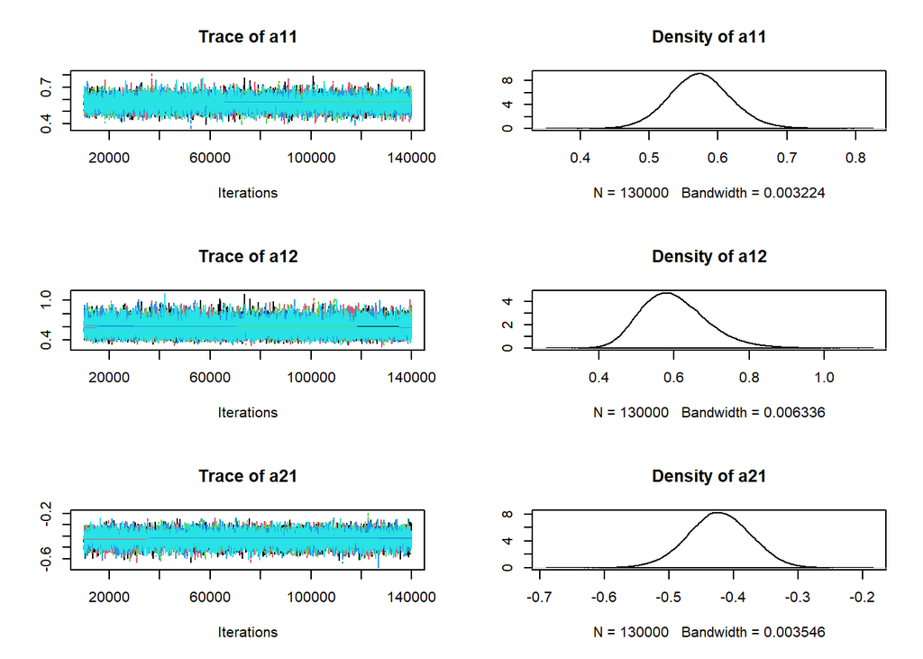

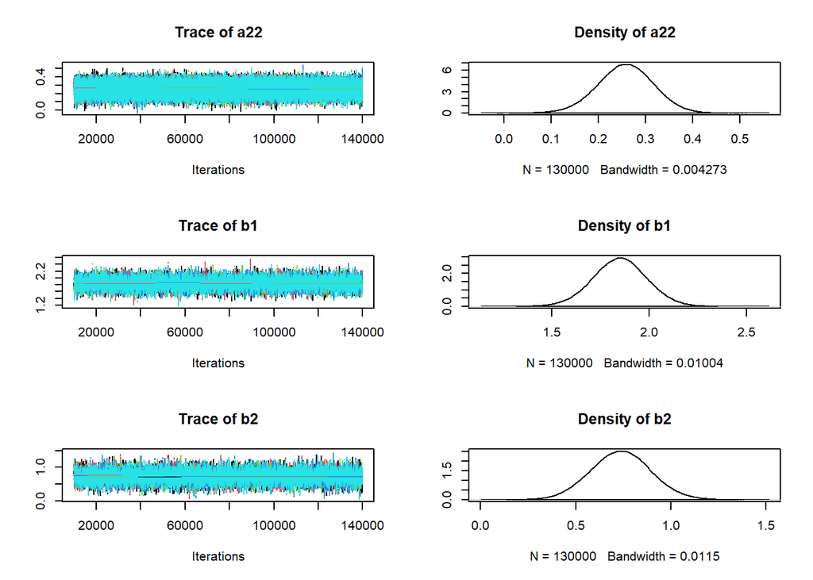

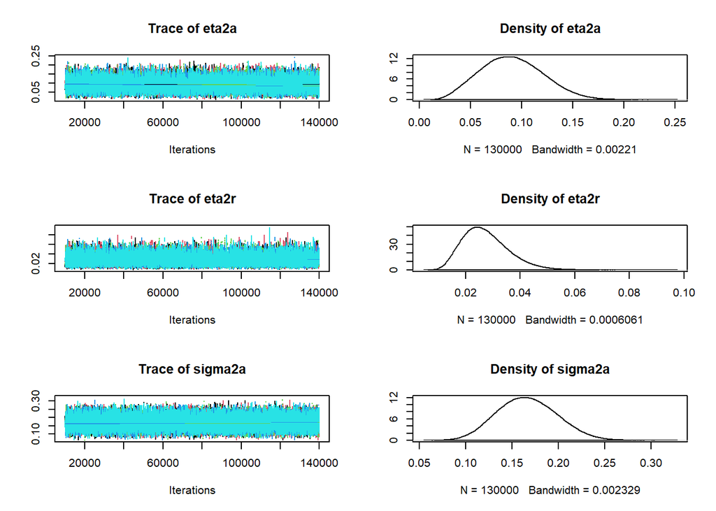

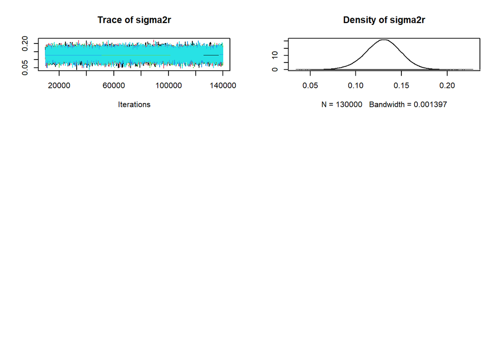

```r
#Computing Trace plot for each parameters
par(mfrow=c(1,1))
plot(res.chain)
```

```r
#Computing the Effective sample size.
esize <- c()
for (i in c(1:10)){
  esize <- c(esize, effectiveSize(res.chain[[1]][,i]))
}
esize <- t(data.frame(esize))
colnames(esize) <- colnames(res.chain[[1]])
esize
```

```
##           a11      a12     a21      a22       b1       b2    eta2a    eta2r
## esize 1016.92 1471.695 1181.24 7454.459 1112.129 1162.106 1469.957 3631.088
##        sigma2a  sigma2r
## esize 1696.883 2517.995
```

**c)[10 marks]**

**We are going to perform posterior predictive checks to evaluate the fit of this model on the data (using the priors stated in question a). First, create replicate observations from the posterior predictive using JAGS. The number of replicate observations should be at least 1000.**

**Compute the minimum, maximum, and median for both log-concentrations (i.e. both for rotifier and algae,** $3\cdot 2=6$ **in total).**

**Plot the histograms for these quantities together with a line that shows the value of the function considered on the actual dataset (see the R code for Lecture 2 for an example). Compute the DIC score for the model (Hint: you can use the `dic.samples` function for this).**

**Discuss the results.**

**Explanation**:

The histograms above show posterior predictive distribution for the minimum, maximum and median of rotifier and algae. The values in the observed data set are shown by vertical red lines. The lines seem to be within the typical range of the replicates, showing a reasonably good fit. To evaluate the fit of the model, we computed the Deviance Information Criteria (DIC) value and later we use it for the comparison in part d.

```r
#Defining separate model string to perform posterior predictive check
model.string.replicate <- "model {

x1[1] ~ dnorm(mean.x01, tau.x0)
x2[1] ~ dnorm(mean.x02, tau.x0)

a11 ~ dnorm(mean.a, tau.a)
a12 ~ dnorm(mean.a, tau.a)
a21 ~ dnorm(mean.a, tau.a)
a22 ~ dnorm(mean.a, tau.a)

b1 ~ dnorm(mean.b, tau.b)
b2 ~ dnorm(mean.b, tau.b)

tau.sigma2r ~ dgamma(sigma.a, sigma.b)
tau.sigma2a ~ dgamma(sigma.a, sigma.b)
tau.eta2r ~ dgamma(eta.a, eta.b)
tau.eta2a ~ dgamma(eta.a, eta.b)


sigma2r <- 1/tau.sigma2r
sigma2a <- 1/tau.sigma2a
eta2r <- 1/tau.eta2r
eta2a <- 1/tau.eta2a

for (i in 2:n){
  x1[i] ~ dnorm(a11*x1[i-1] + a12*x2[i-1] + b1, tau.sigma2r)
  x2[i] ~ dnorm(a21*x1[i-1] + a22*x2[i-1] + b2, tau.sigma2a)

}

for (i in 1:n){
  y1[i] ~ dnorm(x1[i], tau.eta2r)
  y1.replicate[i] ~ dnorm(x1[i], tau.eta2r)
  y2[i] ~ dnorm(x2[i], tau.eta2a)
  y2.replicate[i] ~ dnorm(x2[i], tau.eta2a)
}
}"
```

```r
mean.x01 <- log(6)
mean.x02 <- log(1.5)
tau.x0 <- 1/4
mean.a <- mean.b <- 0
tau.a <- tau.b <- 1

sigma.a <- sigma.b <- eta.a <- eta.b <- 0.1

model.data <- list(n = n, y1 = y1, y2 = y2, mean.x01 = mean.x01,
                   mean.x02 = mean.x02, tau.x0 = tau.x0,
                   mean.a = mean.a, tau.a = tau.a,
                   mean.b = mean.b, tau.b = tau.b, sigma.a = sigma.a,
                   sigma.b = sigma.b, eta.a = eta.a, eta.b = eta.b)
```

```r
model.replicate <- jags.model(textConnection(model.string.replicate),
                    data = model.data, n.chains = 5)
#MCMC Sampling with burnin 10000 and 10000 iterations to perform
#posterior predictive checks
update(model.replicate, 10000, progress.bar = "none")
res.replicate <- coda.samples(model.replicate,
                        variable.names=c("y1.replicate", "y2.replicate"),
                        n.iter = 10000 , progress.bar = "none")
```

```r
#convert the output into a matrix
resmat <- as.matrix(res.replicate)
resmat.y1.replicate <- as.matrix(res.replicate[,1:376])
resmat.y2.replicate <- as.matrix(res.replicate[,377:752])
niterf <- nrow(resmat)

#Compute posterior predictive distribution of min, max and median #log(concentration) of rotifier
yrep1 <- t(resmat.y1.replicate[1:niterf,1:n])
yrep1min <- apply(yrep1,2,min)
yrep1max <- apply(yrep1,2,max)
yrep1median <- apply(yrep1,2,median)

#Compute posterior predictive distribution of min, max and median #log(concentration) of algae
yrep2 <- t(resmat.y2.replicate[1:niterf,1:n])
yrep2min <- apply(yrep2,2,min)
yrep2max <- apply(yrep2,2,max)
yrep2median <- apply(yrep2,2,median)
```

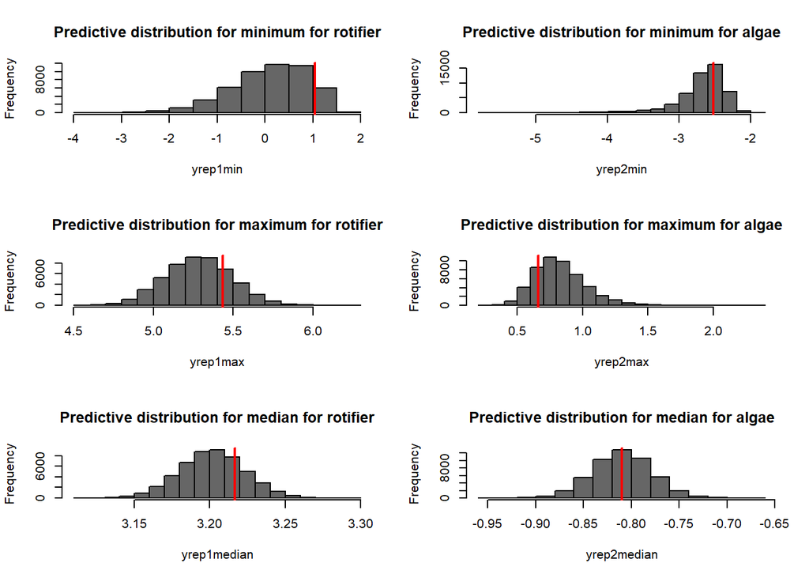

```r
par(mfrow=c(3,2))
hist(yrep1min, col = "gray40",
     main = "Predictive distribution for minimum for rotifier")
abline(v = min(na.omit(y1)),col = "red",lwd = 2)
hist(yrep2min, col = "gray40",
     main = "Predictive distribution for minimum for algae")
abline(v = min(na.omit(y2)),col = "red",lwd = 2)
hist(yrep1max,col = "gray40",
     main = "Predictive distribution for maximum for rotifier")
abline(v = max(na.omit(y1)),col = "red",lwd = 2)
hist(yrep2max,col = "gray40",
     main = "Predictive distribution for maximum for algae")
abline(v = max(na.omit(y2)),col = "red",lwd = 2)
hist(yrep1median,col="gray40",
     main = "Predictive distribution for median for rotifier")
abline(v = median(na.omit(y1)),col = "red",lwd = 2)
hist(yrep2median,col="gray40",
     main = "Predictive distribution for median for algae")
abline(v = median(na.omit(y2)),col = "red",lwd = 2)
```

```r
dic.samples(model.replicate, n.iter = 10000, progress.bar = "none")
```

```
## Mean deviance:  -162.9
## penalty 593.1
## Penalized deviance: 430.2
```

**d)[10 marks]**

**Discuss the meaning of the** **model parameters** $\mathbf{A}, \mathbf{b}, \sigma_R^2, \sigma_A^2, \eta_R^2, \eta_A^2$**. Find a website or paper that that contains information about rotifiers and unicellular algae (Hint: you can use Google search for this). Using your understanding of the meaning of model parameters and the biological information about these organisms, construct more informative prior distributions for the model parameters. State in your report the source of information and the rationale for your choices of priors.**

**Re-implement the JAGS model with these new priors. Perform the same posterior predictive checks as in part c) to evaluate the fit of this new model on the data.**

**Compute the DIC score for the model as well (Hint: lower DIC score indicates better fit on the data).**

**Discuss whether your new priors have improved the model fit compared to the original prior from a).**

**Explanation**:

We refer to the work presented by [Blasius et al. 2020](https://www.nature.com/articles/s41586-019-1857-0) and [Fussmannn et al. 2019](https://www.frontiersin.org/articles/10.3389/fevo.2018.00234/full).

The paper suggests that the diagonal terms of $A$ are the mortality rate and predator assimilation efficacy for rotifier and algae respectively. Also, $b$ is the maximal growth rate of rotifier and algae . The off-diagonal terms of $A$ will remain the same and different to the paper. This is because the paper uses a more complex model accounting for nitrogen, rotifier and algae whereas our models were simplified to rotifier and algae specifically. Then, we employ the initial values that were suggested in from the paper and the model string is as below.

Thus, the implementation with the priors are shown below.

$$\begin{equation}
\begin{split}
\mathbf{A_{11}}&\sim N(0.15, 1) \\
\mathbf{A_{12}}&\sim N(0, 1) \\
\mathbf{A_{21}}&\sim N(0, 1) \\
\mathbf{A_{22}}&\sim N(0.25, 1) \\
\mathbf{b}_t&\sim N\left(\left(
\begin{matrix}
log(2.25) \\ log(3.3)
\end{matrix}
\right),\left(
\begin{matrix}
1 & 0 \\ 0 & 1
\end{matrix}
\right)\right) \\
\end{split}
\end{equation}$$

```r
#new model string defined.
model.string.fussmann <- "model {

x1[1] ~ dnorm(mean.x01, tau.x0)
x2[1] ~ dnorm(mean.x02, tau.x0)

a11 ~ dnorm(mean.a11, tau.a)
a12 ~ dnorm(mean.a12, tau.a)
a21 ~ dnorm(mean.a21, tau.a)
a22 ~ dnorm(mean.a22, tau.a)

b1 ~ dnorm(mean.b1, tau.b)
b2 ~ dnorm(mean.b2, tau.b)

tau.sigma2r ~ dgamma(sigma.a, sigma.b)
tau.sigma2a ~ dgamma(sigma.a, sigma.b)
tau.eta2r ~ dgamma(eta.a, eta.b)
tau.eta2a ~ dgamma(eta.a, eta.b)

sigma2r <- 1 / tau.sigma2r
sigma2a <- 1 / tau.sigma2a
eta2r <- 1 / tau.eta2r
eta2a <- 1 / tau.eta2a

for (i in 2:n){
  x1[i] ~ dnorm(a11 * x1[i-1] + a12 * x2[i-1] + b1, tau.sigma2r)
  x2[i] ~ dnorm(a21 * x1[i-1] + a22 * x2[i-1] + b2, tau.sigma2a)

}

for (i in 1:n){
  y1[i] ~ dnorm(x1[i], tau.eta2r)
  y1.replicate[i] ~ dnorm(x1[i], tau.eta2r)
  y2[i] ~ dnorm(x2[i], tau.eta2a)
  y2.replicate[i] ~ dnorm(x2[i], tau.eta2a)
}
}"
```

```r
#reinitialising the total number of days and log concentration vector.
n <- nrow(rotifier_algae) + 1
y1 <- c(NA, log(rotifier_algae[, 3]))
y2 <- c(NA, log(rotifier_algae[, 2]))

#using the same initial values for x, sigma2 and eta2
mean.x01 <- log(6); mean.x02 <- log(1.5); tau.x0 <- 1/4
sigma.a <- sigma.b <- eta.a <- eta.b <- 0.1

#initialising A with new values
mean.a11 <- 0.15; mean.a22 <- 0.25
mean.a12 <- mean.a21 <- 0

#initialising b with new value
mean.b1 <- log(2.25); mean.b2 <- log(3.3)
tau.a <- tau.b <- 1



model.data <- list(n = n, y1 = y1, y2 = y2, mean.x01 = mean.x01,
                   mean.x02 = mean.x02, tau.x0 = tau.x0,
                   mean.a11 = mean.a11, mean.a12 = mean.a12,
                   mean.a21 = mean.a21, mean.a22 = mean.a22,
                   tau.a = tau.a, mean.b1 = mean.b1, mean.b2 = mean.b2,
                   tau.b = tau.b, sigma.a = sigma.a,
                   sigma.b = sigma.b, eta.a = eta.a, eta.b = eta.b)
```

```r
#Defining the model with more informative prior with 5 chains.
model.fussmann <- jags.model(textConnection(model.string.fussmann),
                    data = model.data, n.chains = 5)
#sampling for posterior predictive checks with burning value of 10000 and
#10000 iterations
update(model.fussmann, 10000, progress.bar = "none")
res.fussmann <- coda.samples(model.fussmann,
                        variable.names = c("y1.replicate", "y2.replicate"),
                        n.iter = 10000, progress.bar = "none")
```

```r
#convert the output into a matrix
resmat <- as.matrix(res.fussmann)
resmat.y1.replicate <- as.matrix(res.fussmann[,1:376])
resmat.y2.replicate <- as.matrix(res.fussmann[,377:752])
niterf <- nrow(resmat)

#Compute posterior predictive distribution of min, max and median
#log(concentration) of rotifier
yrep1 <- t(resmat.y1.replicate[1:niterf,1:n])
yrep1min <- apply(yrep1,2,min)
yrep1max <- apply(yrep1,2,max)
yrep1median <- apply(yrep1,2,median)

#Compute posterior predictive distribution of min, max and median #log(concentration) of algae
yrep2 <- t(resmat.y2.replicate[1:niterf,1:n])
yrep2min <- apply(yrep2,2,min)
yrep2max <- apply(yrep2,2,max)
yrep2median <- apply(yrep2,2,median)
```

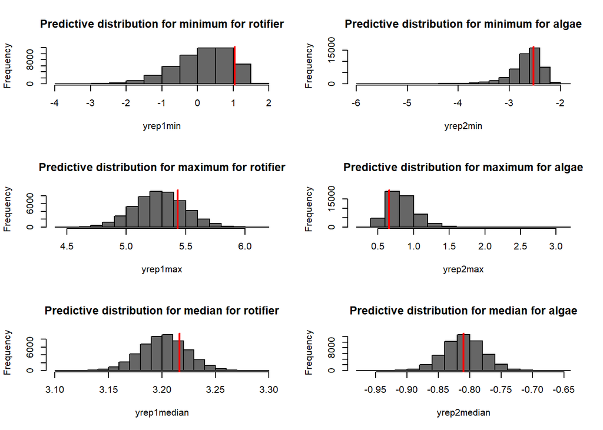

```r
par(mfrow = c(3,2))
hist(yrep1min, col = "gray40",
     main = "Predictive distribution for minimum for rotifier")
abline(v = min(na.omit(y1)), col = "red",lwd = 2)
hist(yrep2min, col = "gray40",
     main = "Predictive distribution for minimum for algae")
abline(v = min(na.omit(y2)), col = "red",lwd = 2)
hist(yrep1max, col = "gray40",
     main = "Predictive distribution for maximum for rotifier")
abline(v = max(na.omit(y1)), col = "red",lwd = 2)
hist(yrep2max, col = "gray40",
     main = "Predictive distribution for maximum for algae")
abline(v = max(na.omit(y2)), col = "red",lwd = 2)
hist(yrep1median, col = "gray40",
     main="Predictive distribution for median for rotifier")
abline(v = median(na.omit(y1)), col="red",lwd = 2)
hist(yrep2median, col = "gray40",
     main = "Predictive distribution for median for algae")
abline(v = median(na.omit(y2)), col = "red",lwd = 2)
```

```r
dic.samples(model.fussmann, n.iter=10000, progress.bar = "none")
```

```
## Mean deviance:  -168.6
## penalty 599.6
## Penalized deviance: 431.1
```

**e)[10 marks] Update the model with your informative prior in part d) to compute the posterior distribution of the log concentrations sizes (**$\mathbf{x}_t$**) on the days 376-395 (20 additional days).**

**Plot the evolution of the posterior mean of the log concentrations for rotifier and algae during days 376-395 on a single plot, along with curves that correspond to the [2.5%, 97.5%] credible interval of the log concentration size (**$\mathbf{x}_t$**) according to the posterior distribution at each year [Hint: you need** $2+2\cdot 2 = 6$ **curves in total, use different colours for the curves for rotifier and algae].**

**Finally, estimate the posterior probability that the concentration of algae (measured in 10^6 algae/ml, as in the data) becomes smaller than** $0.1$ **at any time during this 20 additional days (days 376-395).**

**Explanation**:

Looking at the plot in between Day $377$ and $380$, when there is a decrease in the concentration of rotifier we observe the increase in the concentration of algae in a given unit. This shows the predator and prey relationship between rotifier and algae. Also to note that we can see that concentration of rotifier and algae in a given unit have reached the equilibrium [Fussmann et al. 2000](http://www.math.pitt.edu/~bard/classes/mth3380/elner.pdf) at Day $382$. As a result, the model predicts the coexistence at an equilibrium for both rotifiers and algae in a predator and prey settings.

```r
n <- nrow(rotifier_algae) + 1
y1 <- c(NA, log(rotifier_algae[, 3]))
y2 <- c(NA, log(rotifier_algae[, 2]))

#adding additional 20 values for prediction
n <- n + 20
y.pred <- rep(NA, 1*20)
y1 <- c(y1, y.pred)
y2 <- c(y2, y.pred)

mean.x01 <- log(6)
mean.x02 <- log(1.5)
tau.x0 <- 1/4
mean.a11 <- 0.15
mean.a12 <- mean.a21 <- 0
mean.a22 <- 0.25
mean.b1 <- log(2.25)
mean.b2 <- log(3.3)
tau.a <- tau.b <- 1

sigma.a <- sigma.b <- eta.a <- eta.b <- 0.1

model.data <- list(n = n, y1 = y1, y2 = y2, mean.x01 = mean.x01,
                   mean.x02 = mean.x02, tau.x0 = tau.x0,
                   mean.a11 = mean.a11, mean.a12 = mean.a12,
                   mean.a21 = mean.a21, mean.a22 = mean.a22,
                   tau.a = tau.a, mean.b1 = mean.b1, mean.b2 = mean.b2,
                   tau.b = tau.b, sigma.a = sigma.a,
                   sigma.b = sigma.b, eta.a = eta.a, eta.b = eta.b)
```

```r
#Defining the model for prediction with 5 chains
model.pred<- jags.model(textConnection(model.string.fussmann),
                    data = model.data, n.chains = 5)
#performing MCMC sampling to predict the log concentration of rotifiers and algae
update(model.pred, 10000, progress.bar = "none")
res.predict <- coda.samples(model.pred,
                        variable.names = c("y1", "y2"),
                        n.iter = 10000, progress.bar="none")
```

```r
#We compute the posterior means and the 95% credible interval
res.summary <- summary(res.predict)
y1.mean <- res.summary$statistics[377:396,1]
y1.q025 <- res.summary$quantiles[377:396,1]
y1.q975 <- res.summary$quantiles[377:396,5]
y2.mean <- res.summary$statistics[773:792,1]
y2.q025 <- res.summary$quantiles[773:792,1]
y2.q975 <- res.summary$quantiles[773:792,5]
```

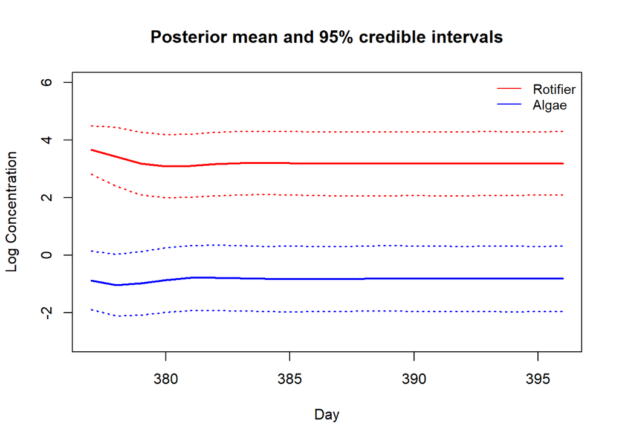

```r
#plotting the posterior mean and confidence intervals of rotifiers and algae respectively
plot(377:396, y1.mean, type="l", ylim = c(-3,6), lwd = 2,
     col = "red", main = "Posterior mean and 95% credible intervals",
     xlab = "Day", ylab = "Log Concentration")
lines(377:396, y1.q025, lty = 3, lwd = 1.5, col = "red")
lines(377:396, y1.q975, lty = 3, lwd = 1.5, col = "red")
lines(377:396, y2.mean, type = "l", lwd = 2, col = "blue")
lines(377:396, y2.q025, lty = 3, lwd = 1.5, col = "blue")
lines(377:396, y2.q975, lty = 3, lwd = 1.5, col = "blue")
  legend("topright", legend = c("Rotifier", "Algae"),
         col = c("red", "blue"), lty = 1, cex = 0.9, bty = "n")
```

```r
#estimate the posterior probability that the concentration of
#algae becomes smaller than 0.1
algae.samp <- data.frame(rbind(res.predict[[1]][,773:792],
                               res.predict[[2]][,773:792],
                               res.predict[[3]][,773:792],
                               res.predict[[4]][,773:792],
                               res.predict[[5]][,773:792]))
algae.min <- apply(algae.samp, MARGIN = 1, FUN = min)
mean(exp(algae.min) < 0.1)
```

```
## [1] 0.10326
```

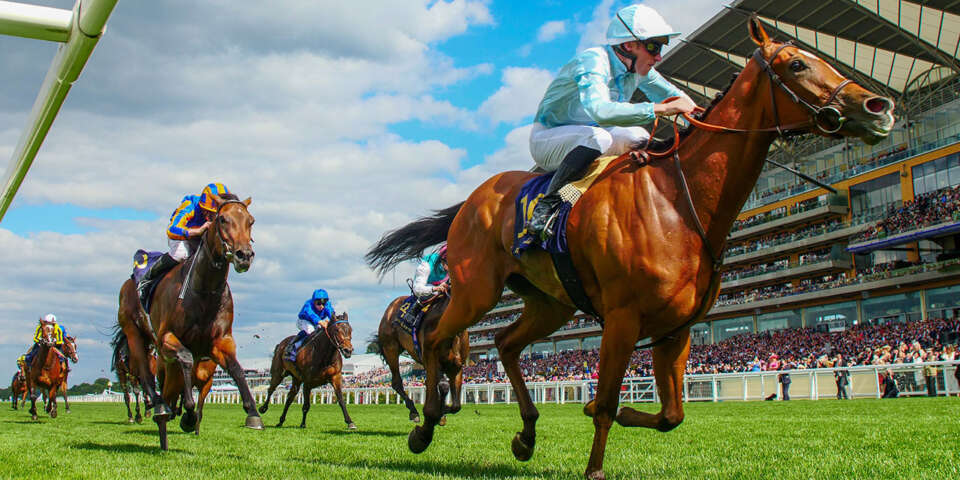

**Problem 2 - Horse racing data**

**In this problem, we are going to construct a predictive model for horse races. The dataset (races.csv and runs.csv) contains the information about 1000 horse races in Hong Kong during the years 1997-1998 (originally from https://www.kaggle.com/gdaley/hkracing). Races.csv contains information about each race (such as distance, venue, track conditions, etc.), while runs.csv contains information about each horse participating in each race (such as finish time in the race). Detailed description of all columns in these files is available in the file horse_racing_data_info.txt.**

**Our goal is to model the mean speed of each horse during the races based on covariates available before the race begins.**

**We are going to use INLA to fit several different regression models to this dataset. First, we load ILNA and the datasets and display the first few rows.**

```r
runs <- read.csv(file = 'runs.csv')
races<- read.csv(file = 'races.csv')
```

**a)[10 marks] Create a dataframe that includes the mean speed of each horse in each race and the distance of the race in a column [Hint: you can do this adding two extra columns to the runs dataframe].**

**Fit a linear regression model (lm) with the mean speed as a response variable. The covariates should be the horse id as a categorical variable, and the race distance, horse rating, and horse age as standard variable. Scale the non-categorical covariates before fitting the model (i.e. center and divide by their standard deviation, you can use the** `scale` **function in R for this).**

**Print out the summary of the lm model, discuss the quality of the fit.**

**Explanation**:

```r
#merging the two data sets by race_id and distance
runs.speed <- merge(runs, races[, c("race_id","distance")],
                    by = "race_id", all.x = TRUE)
#computing the mean speed
runs.speed$speed <- runs.speed$distance / runs.speed$finish_time
#making horse_id a factor as it is a categorical variable
runs.speed$horse_id <- as.factor(runs.speed$horse_id)
head(runs.speed, 5)
```

```
##   race_id horse_no horse_id result won lengths_behind horse_age horse_country
## 1       0        1     3917     10   0           8.00         3           AUS
## 2       0        2     2157      8   0           5.75         3            NZ
##   horse_type horse_rating horse_gear declared_weight actual_weight draw
## 1    Gelding           60         --            1020           133    7
## 2    Gelding           60         --             980           133   12
##   position_sec1 position_sec2 position_sec3 position_sec4 position_sec5
## 1             6             4             6            10            NA
## 2            12            13            13             8            NA
##   position_sec6 behind_sec1 behind_sec2 behind_sec3 behind_sec4 behind_sec5
## 1            NA         2.0           2         1.5        8.00          NA
## 2            NA         6.5           9         5.0        5.75          NA
##   behind_sec6 time1 time2 time3 time4 time5 time6 finish_time win_odds
## 1          NA 13.85 21.59 23.86 24.62    NA    NA       83.92      9.7
## 2          NA 14.57 21.99 23.30 23.70    NA    NA       83.56     16.0
##   place_odds trainer_id jockey_id distance    speed
## 1        3.7        118         2     1400 16.68255
## 2        4.9        164        57     1400 16.75443
##  [ reached 'max' / getOption("max.print") -- omitted 3 rows ]
```

```r
#fitting the linear model with given values.
fit <- lm(speed ~ horse_id + scale(distance) +
            scale(horse_rating) + scale(horse_age),
          data = runs.speed)

fit.summary <- summary(fit)
fit.summary
```

```
##
## Call:
## lm(formula = speed ~ horse_id + scale(distance) + scale(horse_rating) +
##     scale(horse_age), data = runs.speed)
##
## Residuals:
##      Min       1Q   Median       3Q      Max
## -2.64378 -0.09259  0.01438  0.11849  0.59029
##
## Coefficients:
##                       Estimate Std. Error  t value Pr(>|t|)
## (Intercept)          1.669e+01  4.461e-02  374.039  < 2e-16 ***
## horse_id29          -1.449e-01  7.197e-02   -2.013 0.044162 *
## horse_id61          -2.604e-01  1.114e-01   -2.338 0.019404 *
## horse_id62          -9.859e-02  1.016e-01   -0.970 0.331919
## horse_id63          -8.021e-02  8.924e-02   -0.899 0.368752
## horse_id64           6.383e-02  1.510e-01    0.423 0.672519
## horse_id65          -1.070e-01  1.015e-01   -1.054 0.292048
## horse_id66          -6.092e-02  8.905e-02   -0.684 0.493931
## horse_id67          -7.032e-02  8.490e-02   -0.828 0.407527
## horse_id69          -1.243e+00  2.087e-01   -5.956 2.67e-09 ***
## horse_id70           1.308e-01  1.041e-01    1.257 0.208848
## horse_id72          -8.189e-03  7.200e-02   -0.114 0.909452
## horse_id79          -2.675e-01  1.258e-01   -2.127 0.033463 *
## horse_id80           3.551e-02  7.831e-02    0.453 0.650228
## horse_id82           1.316e-01  6.547e-02    2.010 0.044455 *
## horse_id91          -2.694e-02  1.016e-01   -0.265 0.790933
## horse_id92           2.178e-01  1.016e-01    2.144 0.032079 *
## horse_id93           7.120e-02  6.650e-02    1.071 0.284323
## horse_id94          -2.626e-02  8.896e-02   -0.295 0.767818
## horse_id95          -1.136e-01  6.665e-02   -1.704 0.088333 .
##  [ reached getOption("max.print") -- omitted 1415 rows ]
## ---
## Signif. codes:  0 '***' 0.001 '**' 0.01 '*' 0.05 '.' 0.1 ' ' 1
##
## Residual standard error: 0.2038 on 11109 degrees of freedom
## Multiple R-squared:  0.7883, Adjusted R-squared:  0.761
## F-statistic: 28.85 on 1434 and 11109 DF,  p-value: < 2.2e-16
```

```r
#computing the total number of variables
nrow(fit.summary$coefficients)
```

```
## [1] 1435
```

```r
#computing the number of variables with p-value > 0.05
sum(fit.summary$coefficients[, 4] > 0.05)
```

```
## [1] 992
```

**b)[10 marks] Fit the same model in INLA (i.e. Bayesian linear regression with Gaussian likelihood, mean speed is the response variable, and the same covariates used with scaling for the non-categorical covariates). Set a Gamma (0.1,0.1) prior for the precision, and Gaussian priors with mean zero and variance 1000000 for all of the regression coefficients (including the intercept).**

**Print out the summary of the INLA model. Compute the posterior mean of the variance parameter** $\sigma^2$**. Plot the posterior density for the variance parameter** $\sigma^2$**. Compute the negative sum log CPO (NSLCPO) and DIC values for this model (smaller values indicate better fit).**

**Compute the standard deviation of the mean residuals (i.e. the differences between the posterior mean of the fitted values and the true response variable).**

**Discuss the results.**

**Explanation**:

To that, we computed the negative sum log CPO and DIC. We also plotted the posterior density of sigma and computed the standard deviation of the mean residual of the fitted values. The summary statistics were obtained by `inla.zmarginal`, and the value of $0.1918068$. This is similar to the value we had with the `lm()` model.

```r
prec.prior <- list(prec = list(prior = "loggamma", param = c(0.1, 0.1)))

prior.beta <- list(mean.intercept = 0, prec.intercept = 1/1000000,
                    mean = 0, prec = 1/1000000)

fit.inla <- inla(speed ~ horse_id + scale(distance) +
                   scale(horse_rating) + scale(horse_age),
                 data = runs.speed, family = "Gaussian",
                 control.compute = list(config = TRUE, cpo = TRUE, dic = TRUE),
                 control.family = list(hyper=prec.prior),
                 control.fixed = prior.beta)
```

```r
#Computing the summary statistics
summary(fit.inla)
```

```
##
## Call:
##    c("inla(formula = speed ~ horse_id + scale(distance) +
##    scale(horse_rating) + ", " scale(horse_age), family = \"Gaussian\",
##    data = runs.speed, ", " control.compute = list(config = TRUE, cpo =
##    TRUE, dic = TRUE), ", " control.family = list(hyper = prec.prior),
##    control.fixed = prior.beta)" )
## Time used:
##     Pre = 6.43, Running = 28.1, Post = 14.3, Total = 48.8
## Fixed effects:
##                       mean    sd 0.025quant 0.5quant 0.975quant   mode kld
## (Intercept)         16.687 0.045     16.599   16.687     16.774 16.687   0
## horse_id29          -0.145 0.072     -0.286   -0.145     -0.004 -0.145   0
## horse_id61          -0.260 0.111     -0.479   -0.260     -0.042 -0.260   0
## horse_id62          -0.099 0.102     -0.298   -0.099      0.101 -0.099   0
## horse_id63          -0.080 0.089     -0.255   -0.080      0.095 -0.080   0
## horse_id64           0.064 0.151     -0.233    0.064      0.360  0.064   0
## horse_id65          -0.107 0.102     -0.306   -0.107      0.092 -0.107   0
## horse_id66          -0.061 0.089     -0.236   -0.061      0.114 -0.061   0
## horse_id67          -0.070 0.085     -0.237   -0.070      0.096 -0.070   0
## horse_id69          -1.243 0.209     -1.653   -1.243     -0.833 -1.243   0
## horse_id70           0.131 0.104     -0.074    0.131      0.335  0.131   0
## horse_id72          -0.008 0.072     -0.150   -0.008      0.133 -0.008   0
## horse_id79          -0.268 0.126     -0.515   -0.268     -0.021 -0.268   0
## horse_id80           0.036 0.078     -0.118    0.036      0.189  0.036   0
##  [ reached getOption("max.print") -- omitted 1421 rows ]
##
## Model hyperparameters:
##                                          mean    sd 0.025quant 0.5quant
## Precision for the Gaussian observations 24.07 0.318      23.44    24.06
##                                         0.975quant  mode
## Precision for the Gaussian observations      24.69 24.06
##
## Deviance Information Criterion (DIC) ...............: -2941.65
## Deviance Information Criterion (DIC, saturated) ....: 415241.95
## Effective number of parameters .....................: 1399.25
##
## Marginal log-Likelihood:  -10677.46
## CPO and PIT are computed
##
## Posterior summaries for the linear predictor and the fitted values are computed
## (Posterior marginals needs also 'control.compute=list(return.marginals.predictor=TRUE)')
```

```r
#sigma for the Gaussian observation
marg.sigma <- inla.tmarginal(function(tau) tau^(-1),
  fit.inla$marginals.hyperpar[[1]])
#summary staistics of sigma
inla.zmarginal(marg.sigma)
```

```
## Mean            0.0415617
## Stdev           0.000553345
## Quantile  0.025 0.0404892
## Quantile  0.25  0.041183
## Quantile  0.5   0.0415547
## Quantile  0.75  0.0419329
## Quantile  0.975 0.0426637
```

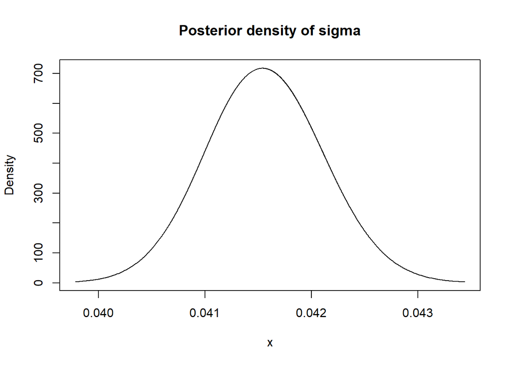

```r
#plotting the posterior density of sigma
plot(marg.sigma, type = "l", xlab = "x", ylab = "Density",
     main = 'Posterior density of sigma')
```

```r
#computing NSLCPO and DIC values
cat("NSLCPO of the model:",-sum(log(fit.inla$cpo$cpo)),"\n")
```

```
## NSLCPO of the model: -1231.675
```

```r
cat("DIC of the model:", fit.inla$dic$dic,"\n")
```

```
## DIC of the model: -2941.646
```

```r
#computing the mean and stddev of the mean residual of the model
mean.res <- runs.speed$speed - fit.inla$summary.fitted.values$mean
sd.res <- sd(mean.res)
cat("Standard deviation of the mean residual of the model:", sd.res,"\n")
```

```
## Standard deviation of the mean residual of the model: 0.1918068
```

**c)[10 marks] In this question, we are going to improve the model in b) by using more informative priors and more columns from the dataset.**

**First, using some publicly available information from the internet (Hint: use Google search) find out about the typical speed of race horses in Hong Kong, and use this information to construct a prior for the intercept. Explain the rationale for your choice.**

**Second, look through all of the information in the datasets that is available before the race (Hint: you need to read the description horse_racing_data_info.txt for information about the columns. position, behind, result, won, and time related columns are not available before the race). Discuss your rationale for including some of these in the dataset (make sure to scale them if they are non-categorical).**

**Feel free to try creating additional covariates such as polynomial or interaction terms (Hint: this can be done using I() in the formula), and you can also try to use a different likelihood (such as Student-t distribution).**

**Fit your new model in INLA (i.e. Bayesian linear regression, mean speed is the response variable, and scaling done for the non-categorical covariates).**

**Print out the summary of the INLA model. Compute the negative sum log CPO (NSLCPO) and DIC values for this model (smaller values indicate better fit).**

**Compute the standard deviation of the mean residuals (i.e. the differences between the posterior mean of the fitted values and the true response variable).**

**Discuss the results and compare your model to the model from b).**

**Please only include your best performing model in the report.**

Explanation:

With some thorough investigation, we referred to the idea in [Silverman et al. 2012](http://www.bjll.org/index.php/jpm/article/download/590/628). The paper employed ordinary least squares to compute the estimate of the regression coefficients. Then it used the Gaussian priors of the mean and standard deviation of the estimates. Similarly, we will use the mean and precision of the fitted value of regression on the dataset to construct the prior of the $\beta$.

With several experiments and intuition, we chose a model with several variables. To name them, we have $horse_id$, $distance$, $distance^2$, $horse_rating$, $horse_age$, $win_odds$, $actual_weight$ and $draw$.

After the fitting, we computed the NSLCPO and DIC. Comparing to the previous part b, we obtained significant decrease in both NSLCPO and DIC values. Therefore, we can conclude that the model in part c is a better fit. Looking at the standard deviation of the mean residual, we had a lower value of $0.1886289$. Overall, the model in part c shows better fit than the model in part b.

```r
prec.prior <- list(prec=list(prior = "loggamma",
                             param = c(0.1, 0.1)))
#Newly assigned prior for beta
prior.beta <- list(mean.intercept = fit.summary$coefficients[1,1],
                   prec.intercept = 1/(fit.summary$coefficients[1,2]^2),
                    mean = 0, prec = 1/1000000)

#fitting in INLA
fit.inla.silverman <- inla(speed ~ horse_id + scale(distance) +
                           scale(I(distance^2)) + scale(horse_rating) +
                           scale(horse_age) + scale(win_odds) +
                           scale(actual_weight) + factor(draw),
                         data = runs.speed,
                         family="gaussian",
                         control.family=list(hyper=prec.prior),
                         control.fixed=prior.beta,
                         control.compute=list(config=TRUE, cpo=TRUE, dic=TRUE))
```

```r
#Computing NSLCPO and DIC values
cat("NSLCPO of the model:",-sum(log(fit.inla.silverman$cpo$cpo)),"\n")
```

```
## NSLCPO of the model: -1424.707
```

```r
cat("DIC of the model:", fit.inla.silverman$dic$dic,"\n")
```

```
## DIC of the model: -3333.58
```

```r
#Computing mean and standard deviation of the mean residual
mean.res <- runs.speed$speed - fit.inla.silverman$summary.fitted.values$mean
sd.res <- sd(mean.res)
cat("Standard deviation of the mean residual of the model:", sd.res,"\n")
```

```
## Standard deviation of the mean residual of the model: 0.1886289
```

**d)[10 marks] We are going to perform model checks to evaluate the fit the two models in parts b) and c) on the data.**

**Compute the studentized residuals for the Bayesian regression model from parts b) and c). Perform a simple Q-Q plot on the studentized residuals. Plot the studentized residuals versus their index, and also plot the studentized residuals against the posterior mean of the fitted value (see Lecture 2). Discuss the results.**

**Explanation**:

We computed normal Q-Q plot of the studentised residuals for the Bayesian regression models in part b and c. By looking at the plots, we can see that the normality assumption holds for both plots as the fit is reasonably good except for the left tail. This indicates the points below the red line are occurring at much lower values compared to where those quantiles would in the Gaussian distribution and shows that it is left skewed.

Looking at the studentised residuals against the index plot shows that the error terms of the models are independent of each other.

Looking at the plot, studentised residuals against the fitted value, both models have the residual mean randomly scattered around zero without a distinctive pattern. This further indicates that linear model is good choice to represent the horse racing dataset. Also, we further conclude the homoscedasticity is determined in the model for the mean.

All in all, we cannot determine the goodness of the fit between the two models from part b and part c as all the 3 plots show close similarities. Thus, the difference in the model is insignificant. However, DIC and NSLCPO values play more significant roles in determining the better model which we showed in part c.

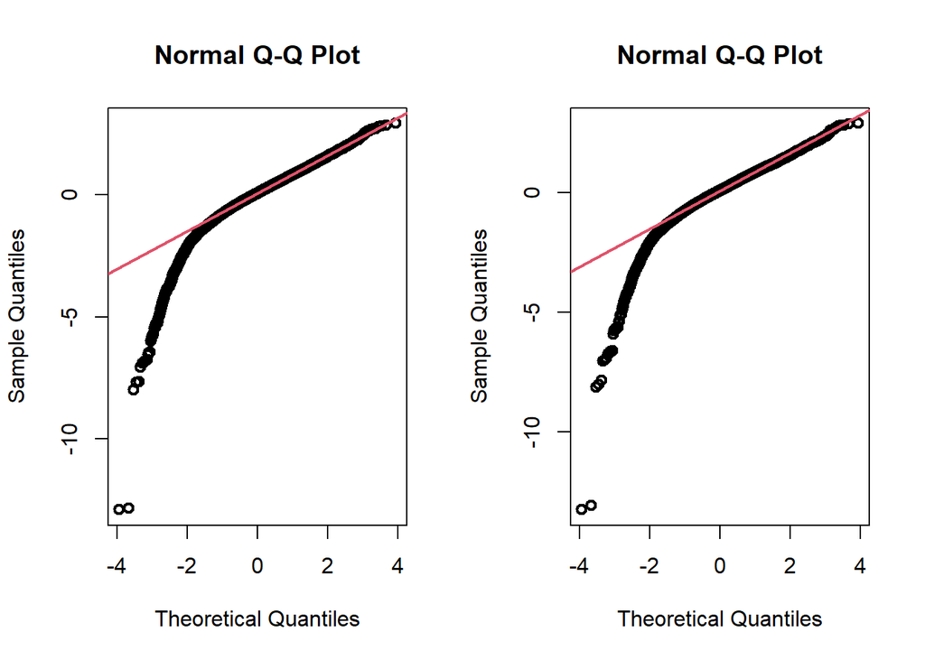

```r
#We obtain the samples from models in part b and c (Silverman)
nbsamp <- 10
race.samp <- inla.posterior.sample(nbsamp, fit.inla)
race.samp.silverman <- inla.posterior.sample(nbsamp, fit.inla.silverman)

sigma <- 1 / sqrt(inla.posterior.sample.eval(function(...) {theta},
  race.samp))
sigma.silverman <- 1 / sqrt(inla.posterior.sample.eval(function(...) {theta},
  race.samp.silverman))

#In this model the link function is the identity, so fitted values are the same as the linear predictors
fittedvalues <- inla.posterior.sample.eval(function(...) {Predictor},
race.samp)
fittedvalues.silverman <- inla.posterior.sample.eval(function(...) {Predictor},
race.samp.silverman)

#n is the number of rows in the dataset
n <- nrow(runs.speed)
x <- cbind(rep(1,n), runs.speed$horse_id,
           scale(runs.speed$distance),
           scale(runs.speed$horse_rating), scale(runs.speed$horse_age))
x.silverman <- cbind(rep(1,n), runs.speed$horse_id,
                           scale(runs.speed$distance),
                           scale(runs.speed$horse_rating),
                           scale((runs.speed$distance)^2),
                           scale(runs.speed$horse_age),
                           scale(runs.speed$win_odds), factor(runs.speed$draw),
                           scale(runs.speed$actual_weight))

H <- x %*%
  solve((t(x) %*% x)) %*% t(x)
H.silverman <- x.silverman %*%
  solve((t(x.silverman) %*% x.silverman)) %*% t(x.silverman)

#studentised residuals
studentisedred <- studentisedred.silverman <- matrix(0, nrow = n, ncol = nbsamp)

#create a matrix of size n * nbsamp, repeating y in each column
y <- runs.speed$speed
ymx <- as.matrix(y) %*% matrix(1, nrow = 1, ncol = nbsamp)

studentisedred <- ymx - fittedvalues
studentisedred.silverman <- ymx - fittedvalues.silverman

for(l in 1:nbsamp){
  studentisedred[,l] <- studentisedred[,l] / sigma[l]
  studentisedred.silverman[,l] <- studentisedred.silverman[,l] /
    sigma.silverman[l]
}

for(i in 1:n){
  studentisedred[i,] <- studentisedred[i,] / sqrt(1-H[i,i])
  studentisedred.silverman[i,] <- studentisedred.silverman[i,] /
    sqrt(1-H.silverman[i,i])
}


#posterior mean of studentised residuals
studentisedredm <- numeric(n)
studentisedredm.silverman <- numeric(n)
for(i in 1:n){
  studentisedredm[i] <- mean(studentisedred[i,])
  studentisedredm.silverman[i] <- mean(studentisedred.silverman[i,])
}

#Plot of normal qqplot to test the normality assumption
par(mfrow=c(1,2))
qqnorm(studentisedredm, lwd = 2)
qqline(studentisedredm, col = 2, lwd = 2)
qqnorm(studentisedredm.silverman,lwd = 2)
qqline(studentisedredm.silverman, col = 2, lwd = 2)
```

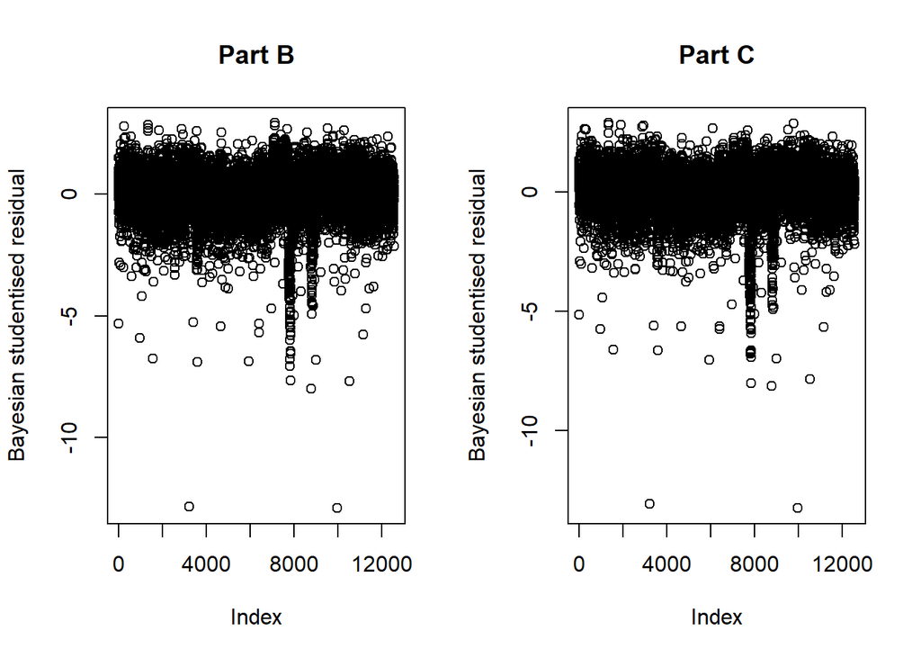

```r
#Plot of posterior mean studentised residual versus observation number.
par(mfrow=c(1,2))
plot(seq_along(studentisedredm), studentisedredm,
     xlab="Index", ylab = "Bayesian studentised residual",
     main = "Part B")
plot(seq_along(studentisedredm.silverman), studentisedredm.silverman,
     xlab = "Index", ylab = "Bayesian studentised residual",
     main = "Part C")
```

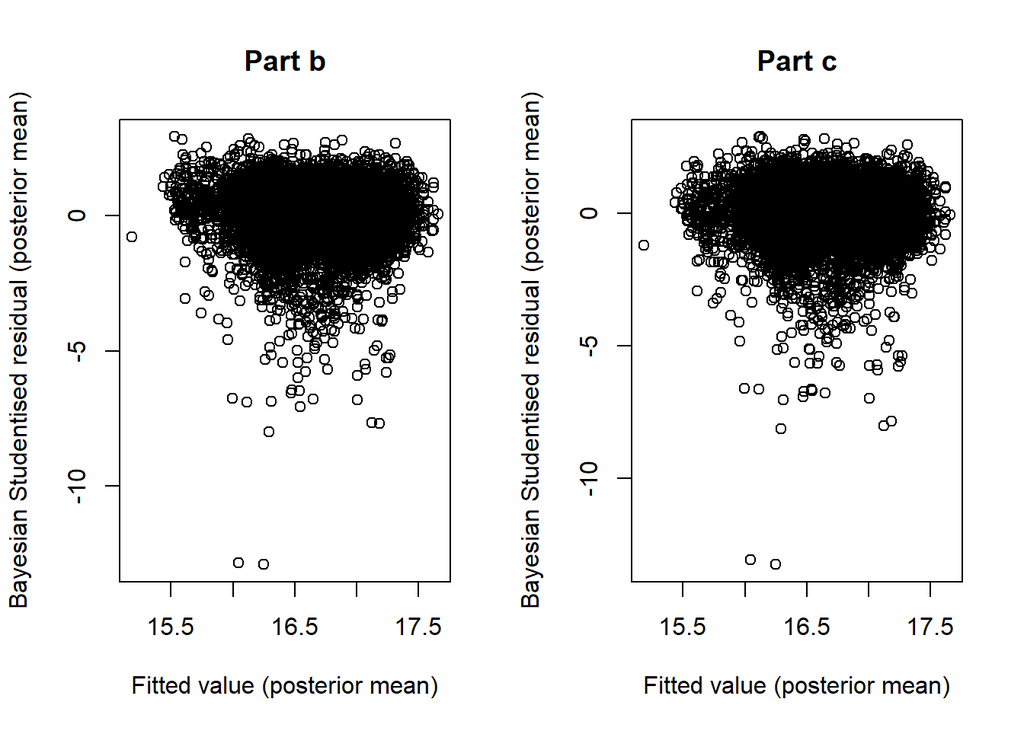

```r
#Compute posterior mean fitted values
fittedvaluesm <- numeric(n)
fittedvaluesm.silverman <- numeric(n)
for(i in 1:n){
  fittedvaluesm[i] <- mean(fittedvalues[i,])
  fittedvaluesm.silverman[i] <- mean(fittedvalues.silverman[i,])
}

par(mfrow=c(1,2))
plot(fittedvaluesm, studentisedredm,
     main = "Part b",
     xlab = "Fitted value (posterior mean)",
     ylab = "Bayesian Studentised residual (posterior mean)")
plot(fittedvaluesm, studentisedredm.silverman,
     main = "Part c",
     xlab = "Fitted value (posterior mean)",
     ylab = "Bayesian Studentised residual (posterior mean)")
```

**e)[10 marks] In this question, we are going to use the model you have constructed in part c) to predict a new race, i.e. calculate the posterior probabilities of each participating horse winning that race. First, we load the dataset containing information about the future race.**

```r
race_to_predict <- read.csv(file = 'race_to_predict.csv')
runs_to_predict <- read.csv(file = 'runs_to_predict.csv')
```

**Based on your model from part c), compute the posterior probabilities of each of these 14 horses winning the race. [Hint: you will need to sample from the posterior predictive distribution.]**

**Explanation**:

We computed the posterior probabilities of each participating horse winning the race by employing the model defined in part c.

Now looking at the table below, we observe that horse $4$ and $5$ have the highest probability of winning the race. The rest of the horses has probability of less than $0.1$ to win the race. Especially, the horses $2$, $3$ and $11$ show the lowest probability among the others.

```r
# Create new columns
runs_to_predict$distance <- rep(race_to_predict$distance, nrow(runs_to_predict))

# mean speed is distance/time
runs_to_predict$horse_id <- as.factor(runs_to_predict$horse_id)
runs_to_predict$speed <- rep(NA,nrow(runs_to_predict))

runs.new <- rbind(runs.speed,runs_to_predict)

prec.prior <- list(prec=list(prior = "loggamma",
                             param = c(0.1, 0.1)))

prior.beta <- list(mean.intercept = fit.summary$coefficients[1,1],
                   prec.intercept = 1 / (fit.summary$coefficients[1,2]^2),
                    mean = 0, prec = 1 / 1000000)

fit.predict <- inla(speed ~ horse_id + scale(distance) +
                      scale(I(distance^2)) + scale(horse_rating) +
                      scale(horse_age) + scale(win_odds) +
                      scale(actual_weight) + factor(draw),
                    data = runs.new,
                    family = "gaussian",
                    control.family = list(hyper = prec.prior),
                    control.fixed = prior.beta,
                    control.compute = list(config = TRUE))

nbsamp <- 10000
fit.predict.sample <- inla.posterior.sample(nbsamp, fit.predict,
                                            selection = list(Predictor=-14:-1))


#Obtain the samples from the linear predictors, which is equivalent
#to the mean of the observations as the link function is the identity here
predictor.samples <- inla.posterior.sample.eval(function(...) {Predictor},
                                             fit.predict.sample)

#We obtain the samples from the parameter sigma using the samples
#from the precision
sigma.samples <- 1/sqrt(inla.posterior.sample.eval(function(...) {theta},
                                                fit.predict.sample))

#We obtain the posterior predictive samples by adding the Gaussian noise
#from the likelihood to the mean (mu_i=eta_i)
post.pred.samples <- matrix(0, nrow = 14, ncol = nbsamp)
for(it in 1:14){
  post.pred.samples[it,] <- predictor.samples[it,] +
    rnorm(nbsamp, mean = 0,sd = sigma.samples)
}

max.post.pred.samples <- sapply(data.frame(post.pred.samples), which.max)
table(max.post.pred.samples)/10000
```

```
## max.post.pred.samples
##      1      2      3      4      5      6      7      8      9     10     11
## 0.0478 0.0230 0.0301 0.2178 0.2113 0.0379 0.0472 0.0566 0.0634 0.0327 0.0297
##     12     13     14
## 0.0617 0.0880 0.0528
```